# Intro to DS - Hypothesis Tests, T-test, 2-sample T-test, ANOVA, Chi-squared

Edwin Lo, GWU Intro to Data Science DATS 6101

2022-03-11

# HW Assignment - Hypothesis Testing

This exercise uses the same graduate school admissions dataset from last homework. The dataset is LogRegAdmit.csv.  
The variables in the dataset are:

- `admit`: 0 or 1 (False or True)
- `gre`: gre score
- `gpa`: grade point average at undergraduate level
- `rank`: the ranking of the applicant’s undergraduate institute, 1, 2, 3, or 4

## Grad School Admissions

### Question 1

**Same as last homework, import the dataset as Adata, and make sure the data type for the variables are set properly for categorical variables.**

```r
Adata <- data.frame(read.csv(file='LogRegAdmit.csv',
                              header=T,
                              sep=',',
                              fill=T,
                              strip.white=T,
                              blank.lines.skip=T,
                              colClasses=c('admit'='factor', 'rank'='factor')))
rmarkdown::paged_table(head(Adata, n=3))
```

|  | admit | gre | gpa | rank |
| --- | --- | --- | --- | --- |
| 1 | 0 | 380 | 3.61 | 3 |
| 2 | 1 | 660 | 3.67 | 3 |
| 3 | 1 | 800 | 4.00 | 1 |

### Question 2

**Use the `outlierKD2()` function, remove the outliers for gre and gpa. Save the resulting dataframe as Adata2. You will need to do this in two steps, removing outliers for one variable at a time. How many NA values are in gre and in gpa with the resulting dataframe *Adata2*?**

```r
tmp1 <- outlierKD2(df=Adata, var=gre, rm=T, histogram=F)
Adata2 <- outlierKD2(df=tmp1, var=gpa, rm=T, histogram=F)
```

There are 4 NA values in GRE and 1 NA values in GPA

### Question 3

**Like last time, separate the two subsets again, for admitted and rejected.**

```r
Adata2.admit <- Adata2[Adata2[, 'admit']==1, ]
Adata2.reject <- Adata2[Adata2[, 'admit']==0, ]
```

Admitted subgroup:

|  | admit | gre | gpa | rank |
| --- | --- | --- | --- | --- |
| 2 | 1 | 660 | 3.67 | 3 |
| 3 | 1 | 800 | 4.00 | 1 |
| 4 | 1 | 640 | 3.19 | 4 |

Rejected subgroup:

|  | admit | gre | gpa | rank |
| --- | --- | --- | --- | --- |
| 1 | 0 | 380 | 3.61 | 3 |
| 5 | 0 | 520 | 2.93 | 4 |
| 8 | 0 | 400 | 3.08 | 2 |

### Question 4

**We were a little careless last time. Let us check for normality on the numerical variables. Let us use histogram (use `ggplot()`) and QQ-plot (use `qqnorm()`) to check the quantitative variables for the admitted and rejected subsets. Make a brief comment on the results.**

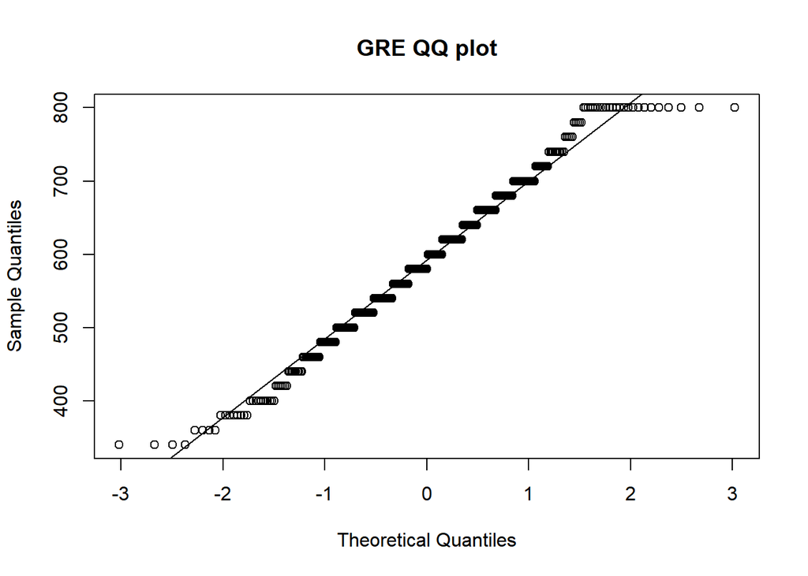

```r
library(ggplot2)

qqnorm(Adata2$gre, main='GRE QQ plot')
qqline(Adata2$gre)
```

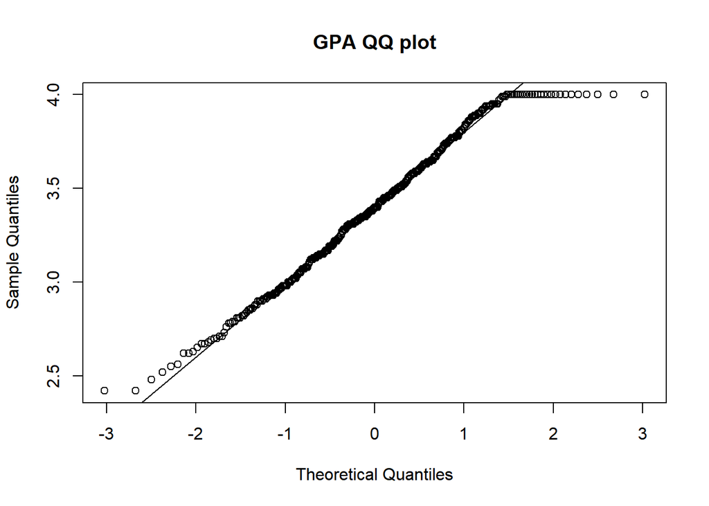

```r
qqnorm(Adata2$gpa, main='GPA QQ plot')
qqline(Adata2$gpa)
```

**GRE**

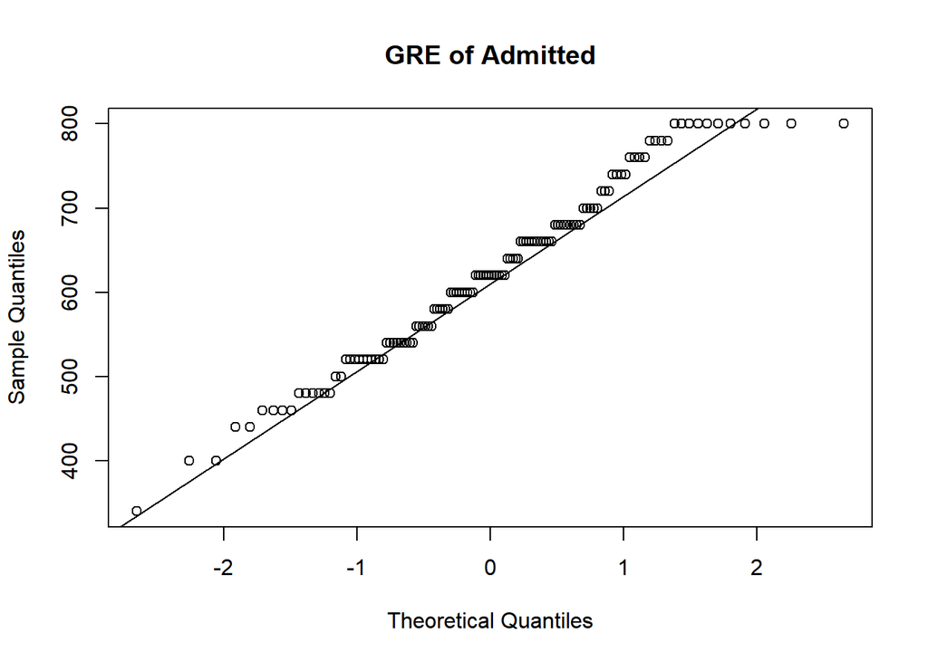

```r
qqnorm(Adata2.admit$gre, main='GRE of Admitted')
qqline(Adata2.admit$gre)
```

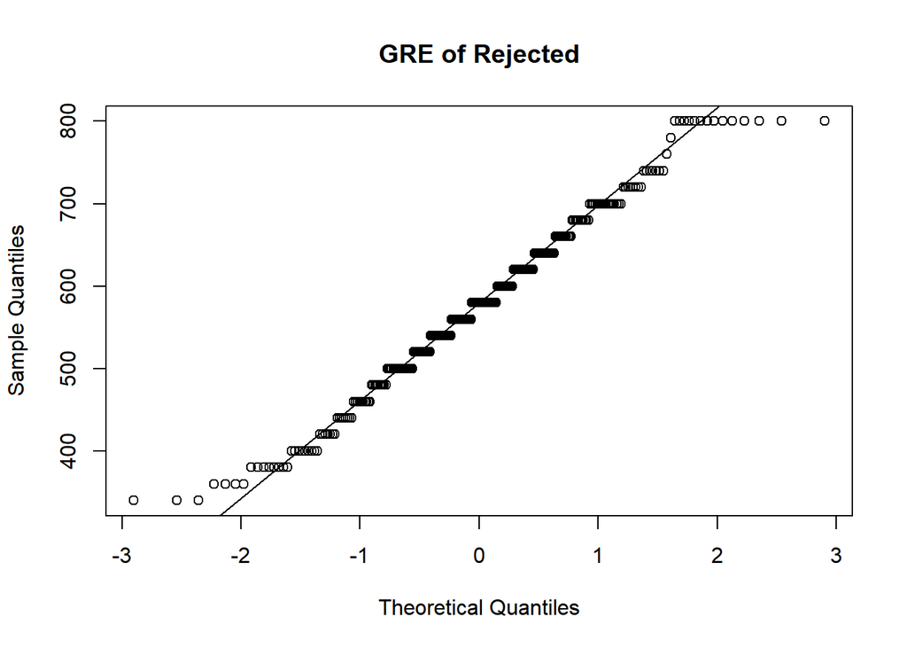

```r
qqnorm(Adata2.reject$gre, main='GRE of Rejected')
qqline(Adata2.reject$gre)
```

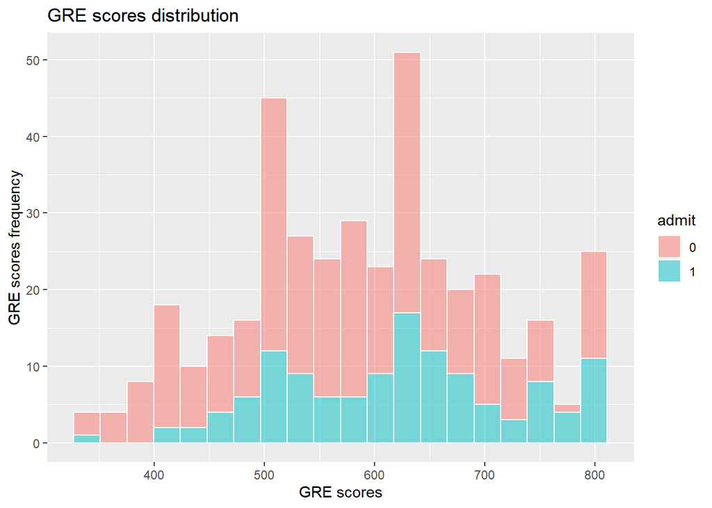

```r
ggplot(Adata2)+
geom_histogram(aes(x=gre, fill=admit), bins=20, color='white', alpha=0.5)+
xlab('GRE scores')+
ylab('GRE scores frequency')+
  labs(title='GRE scores distribution')
```

**GPA**

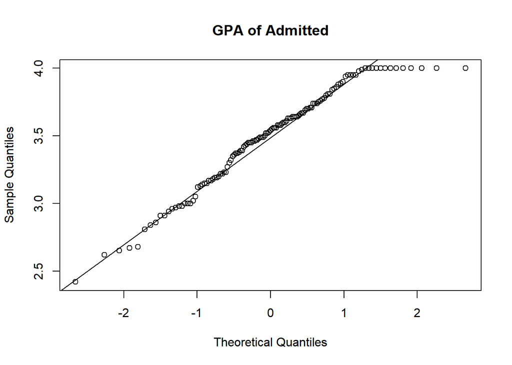

```r
qqnorm(Adata2.admit$gpa, main='GPA of Admitted')
qqline(Adata2.admit$gpa)
```

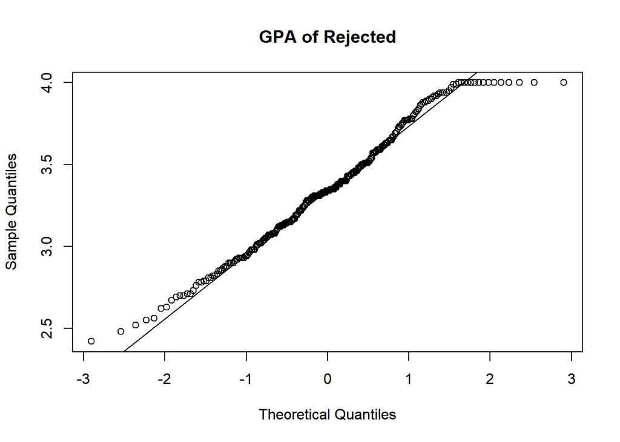

```r
qqnorm(Adata2.reject$gpa, main='GPA of Rejected')
qqline(Adata2.reject$gpa)
```

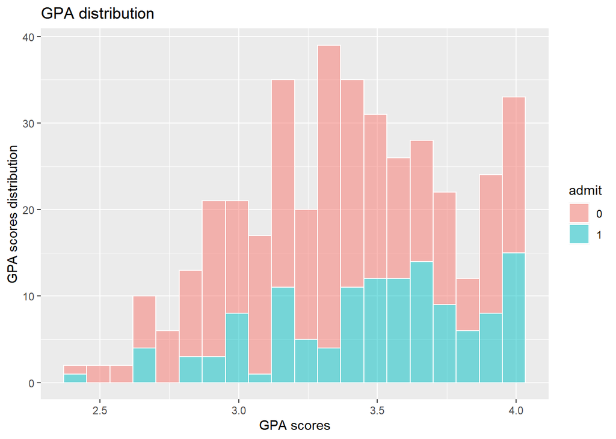

```r
ggplot(Adata2)+
geom_histogram(aes(x=gpa, fill=admit), bins=20, color='white', alpha=0.5)+
xlab('GPA scores')+
ylab('GPA scores distribution')+
  labs(title='GPA distribution')
```

The GRE definitely does not appear normal as systematic deviation is visible from $qqnorm$ and even the histogram shows the distribution makes appearance as multimodal. The GPA does appears normal when $qqnorm$ is applied for the entire population. However, the same does not hold for the admitted subset. Histogram shows for both the subset, this does not represent the normal bell curve. .

### Question 5

**Does the two subgroups have different gre average and gpa average? Use the standard $\alpha$ = 0.05. What are the p-values for the test on gre and gpa? What are your conclusions from the tests?**

```r
alpha <- 0.05
gre <- t.test(Adata2.admit$gre, Adata2.reject$gre)
gpa <- t.test(Adata2.admit$gpa, Adata2.reject$gpa)

null_hyp <- 'We fail to reject Null Hypothesis'
alt_hyp <- 'We reject Null hypothesis in favor of alternative hypothesis'
null_res <- 'there is not enough evidence to confirm that the difference between the two average is statistically significant' # Null hyp
alt_res <- 'the difference between the average of two subsets is not equal to zero'

gre.hyp <- null_hyp
gre.res <- null_res

if (gre$p.value < alpha)
{
  gre.hyp <- alt_hyp
  gre.res <- alt_res

}

gpa.hyp <- null_hyp
gpa.res <- null_res

if (gpa$p.value < alpha)
{
  gpa.hyp <- alt_hyp
  gpa.res <- alt_res
}
```

For GRE, the difference between the average of two subsets is not equal to zero as the p value is 0.000139  
For GPA, the difference between the average of two subsets is not equal to zero as the p value is 0.000458

### Question 6

**With the dataset Adata2, construct a contingency table between rank and admit. Are these two variables qualitative or quantitative?**

Both rank and admit are qualitative variables

**Contingency table**

```r
cont <- table(Adata2$rank, Adata2$admit)
cont
```

```
##
##      0  1
##   1 28 33
##   2 97 54
##   3 93 28
##   4 55 12
```

### Question 7

**Find out whether rank is independent of admission, according to the contingency table above.**

```r
chitest <- chisq.test(cont)
chitest
```

```
##
##  Pearson's Chi-squared test
##
## data:  cont
## X-squared = 25.24, df = 3, p-value = 0.0000137
```

### Question 8

**From *Adata2*, test whether students from the four ranks have the same average gre or not. And also test if they have the same average gpa or not. Remember that if they are not all the same, you will need to follow up with a post hoc test. Make brief comments on your results.** **GRE**

```r
aov.gre <- aov(gre ~ rank, data=Adata2)
summary(aov.gre)
```

```
##              Df  Sum Sq Mean Sq F value Pr(>F)
## rank          3   66231   22077    1.78   0.15
## Residuals   392 4870710   12425
## 4 observations deleted due to missingness
```

```r
gre.posthoc <- TukeyHSD(aov.gre)
gre.posthoc
```

```
##   Tukey multiple comparisons of means
##     95% family-wise confidence level
##
## Fit: aov(formula = gre ~ rank, data = Adata2)
##
## $rank
##          diff      lwr     upr    p adj
## 2-1 -13.80328 -57.4768 29.8702 0.847163
## 3-1 -31.63521 -76.9234 13.6530 0.273781
## 4-1 -37.56085 -88.6410 13.5193 0.230883
## 3-2 -17.83193 -53.1376 17.4737 0.561465
## 4-2 -23.75758 -66.2387 18.7236 0.473344
## 4-3  -5.92564 -50.0652 38.2139 0.985705
```

Since the ANOVA test shows the $Pr(>F)=$ 0.151027 is greater than significance threshold 0.05 for 95% confidence, we fail to reject the null hypothesis. In other words, there is not enough information to conclude that the difference between GRE scores for students from institutions of 4 different ranks is due to more than just a chance.

The Posthoc Honestly Significant Difference test results supports the fact there is not significant difference between gre scores of students from universities of four different ranks.

**GPA**

```r
aov.gpa <- aov(gpa ~ rank, data=Adata2)
summary(aov.gpa)
```

```
##              Df Sum Sq Mean Sq F value Pr(>F)
## rank          3    0.8   0.263    1.86   0.14
## Residuals   395   55.7   0.141
## 1 observation deleted due to missingness
```

```r
gpa.posthoc <- TukeyHSD(aov.gpa)
gpa.posthoc
```

```
##   Tukey multiple comparisons of means
##     95% family-wise confidence level
##
## Fit: aov(formula = gpa ~ rank, data = Adata2)
##
## $rank
##           diff        lwr       upr    p adj
## 2-1 -0.0914591 -0.2384669 0.0555486 0.376879
## 3-1 -0.0202222 -0.1723833 0.1319389 0.986121
## 4-1 -0.1187208 -0.2908247 0.0533831 0.284622
## 3-2  0.0712369 -0.0469934 0.1894673 0.406031
## 4-2 -0.0272617 -0.1702482 0.1157248 0.960875
## 4-3 -0.0984986 -0.2467784 0.0497811 0.317798
```

Since the ANOVA test shows the $Pr(>F)=$ 0.135435 is greater than significance threshold 0.05 for 95% confidence, we fail to reject the null hypothesis. In other words, there is not enough information to conclude that the difference between GPA scores for students from institutions of 4 different ranks is due to more than just a chance.

The Posthoc Honestly Significant Difference test results supports the fact there is not significant difference between GPA scores of students from universities of four different ranks.